# Retention Forecasting Through a Classification Model

The purpose of this project is to predict the users who are most likely to fail an online training course based on data about their performance. To do this, I will use 3 different classification models and compare their prediction accuracy and ROC-AUC.

### Importing libraries

```python
import pandas as pd
import numpy as np
import matplotlib.pyplot as plt
import seaborn as sns
import warnings
warnings.filterwarnings("ignore")
from sklearn import tree
%matplotlib inline
from sklearn.ensemble import RandomForestClassifier
from sklearn.svm import SVC
from sklearn.linear_model import SGDClassifier
from xgboost import XGBClassifier
from sklearn.metrics import confusion_matrix, classification_report,  accuracy_score
from sklearn.preprocessing import StandardScaler, LabelEncoder
from sklearn.model_selection import train_test_split, GridSearchCV, cross_val_score, KFold
from sklearn.neighbors import KNeighborsClassifier
from sklearn.metrics import roc_auc_score, roc_curve, auc
```

```python
sns.set(rc ={'figure.figsize' : (9, 6)})
```

### Reading the data sets

```python
submissions_data = pd.read_csv(r"C:\Users\SilkRIT\Desktop\разное\ML_stepik\Проект ML\submissions_data_train.csv")
events_data = pd.read_csv(r"C:\Users\SilkRIT\Desktop\разное\ML_stepik\Проект ML\event_data_train.csv")
```

```python
submissions_data.head()
```

|  | step_id | timestamp | submission_status | user_id |
| --- | --- | --- | --- | --- |
| 0 | 31971 | 1434349275 | correct | 15853 |
| 1 | 31972 | 1434348300 | correct | 15853 |
| 2 | 31972 | 1478852149 | wrong | 15853 |
| 3 | 31972 | 1478852164 | correct | 15853 |
| 4 | 31976 | 1434348123 | wrong | 15853 |

```python
events_data.head()
```

|  | step_id | timestamp | action | user_id |
| --- | --- | --- | --- | --- |
| 0 | 32815 | 1434340848 | viewed | 17632 |
| 1 | 32815 | 1434340848 | passed | 17632 |
| 2 | 32815 | 1434340848 | discovered | 17632 |
| 3 | 32811 | 1434340895 | discovered | 17632 |
| 4 | 32811 | 1434340895 | viewed | 17632 |

### Data preparation

converting data format

```python
events_data['date'] = pd.to_datetime(events_data['timestamp'], unit ='s')
submissions_data['date'] = pd.to_datetime(submissions_data['timestamp'], unit ='s')
```

checking when course started and the end date of data set

```python
events_data.date.min()
```

```
Timestamp('2015-06-15 04:00:48')
```

```python
events_data.date.max()
```

```
Timestamp('2018-05-19 23:33:31')
```

```python
events_data['day'] = events_data.date.dt.date

submissions_data['day'] = submissions_data.date.dt.date
```

let's see the course attendance

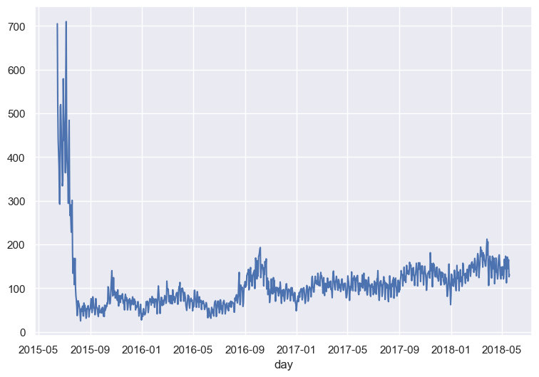

```python
events_data.groupby('day') \
.user_id.nunique().plot()
```

let's see the distribution of users by open steps of the course

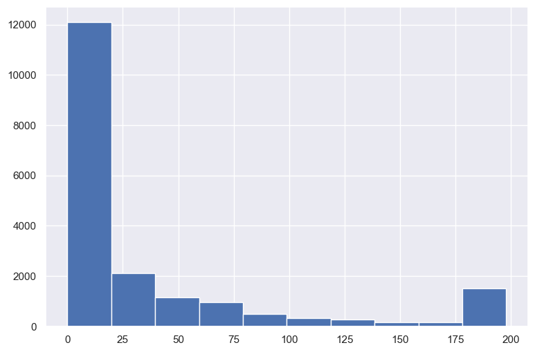

```python
events_data.pivot_table(index ='user_id',
                        columns = 'action',
                        values = 'step_id',
                        aggfunc = 'count',
                        fill_value = 0).reset_index().discovered.hist()
```

now I create the table with distribution of users by submission status of the course

```python
users_scores = submissions_data.pivot_table(index ='user_id',
                        columns = 'submission_status',
                        values = 'step_id',
                        aggfunc = 'count',
                        fill_value = 0).reset_index()
```

Now I want to evaluate the period of user's absence on course, after which we consider that he left it. To do this I will create the distribution of gaps between visits.

```python
events_data[['day','user_id','timestamp']].drop_duplicates(subset = ['user_id', 'day']).head()
```

|  | day | user_id | timestamp |
| --- | --- | --- | --- |
| 0 | 2015-06-15 | 17632 | 1434340848 |
| 36 | 2015-06-15 | 12494 | 1434341931 |
| 59 | 2015-06-15 | 442 | 1434342029 |
| 62 | 2015-06-15 | 22254 | 1434342042 |
| 94 | 2015-06-15 | 6646 | 1434342230 |

```python
gap_data = events_data[['day','user_id','timestamp']].drop_duplicates(subset = ['user_id', 'day']) \
.groupby('user_id')['timestamp'].apply(list)\
.apply(np.diff).values
```

```python
gap_data = pd.Series(np.concatenate(gap_data,axis = 0))
```

```python
gap_data = gap_data /(24*60*60)
```

```python
gap_data
```

```
0         56.060208
1         79.852419
2          2.112083
3          1.084606
4         32.047106
            ...
97867    166.056586
97868      5.845613
97869      1.137176
97870      0.659942
97871     18.148032
Length: 97872, dtype: float64
```

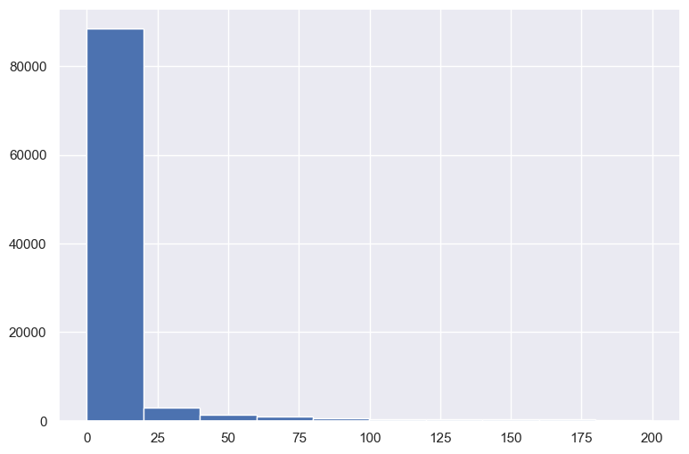

```python
gap_data[gap_data < 200].hist()
```

Now we see 90% of users leave the course after 18 days

```python
# 90% покатдают курс после простоя в 18 дней

gap_data.quantile(0.90)
```

```
18.325995370370403
```

95% leave after 60 days

```python
# 95% покатдают курс после простоя в 60 дней

gap_data.quantile(0.95)
```

```
59.760440972222156
```

For simplicity, let's take a period of 30 days

```python
drop_out_threshold = 30*24*60*60
```

```python
events_data.tail()
```

|  | step_id | timestamp | action | user_id | date | day |
| --- | --- | --- | --- | --- | --- | --- |
| 3480698 | 33375 | 1526772685 | viewed | 11677 | 2018-05-19 23:31:25 | 2018-05-19 |
| 3480699 | 32815 | 1526772750 | viewed | 5198 | 2018-05-19 23:32:30 | 2018-05-19 |
| 3480700 | 32815 | 1526772750 | discovered | 5198 | 2018-05-19 23:32:30 | 2018-05-19 |
| 3480701 | 32815 | 1526772750 | passed | 5198 | 2018-05-19 23:32:30 | 2018-05-19 |
| 3480702 | 33892 | 1526772811 | viewed | 18526 | 2018-05-19 23:33:31 | 2018-05-19 |

```python
# last timestamp
now = 1526772811
```

next I add a column with information whether the user has left or not

```python
users_data = events_data.groupby('user_id', as_index = False) \
.agg({'timestamp' : 'max'}).rename(columns = {'timestamp' : 'last_timestamp'})
```

```python
users_data['is_gone_user'] = (now - users_data.last_timestamp) > drop_out_threshold
```

```python
users_data.head()
```

|  | user_id | last_timestamp | is_gone_user |
| --- | --- | --- | --- |
| 0 | 1 | 1472827464 | True |
| 1 | 2 | 1519226966 | True |
| 2 | 3 | 1444581588 | True |
| 3 | 5 | 1499859939 | True |
| 4 | 7 | 1521634660 | True |

```python
users_scores.head()
```

| submission_status | user_id | correct | wrong |
| --- | --- | --- | --- |
| 0 | 2 | 2 | 0 |
| 1 | 3 | 29 | 23 |
| 2 | 5 | 2 | 2 |
| 3 | 8 | 9 | 21 |
| 4 | 14 | 0 | 1 |

now wee need to join tables with users data and their scores

```python
users_data = users_data.merge(users_scores, on ='user_id', how = 'outer')
```

```python
users_data.head()
```

|  | user_id | last_timestamp | is_gone_user | correct | wrong |
| --- | --- | --- | --- | --- | --- |
| 0 | 1 | 1472827464 | True | NaN | NaN |
| 1 | 2 | 1519226966 | True | 2.0 | 0.0 |
| 2 | 3 | 1444581588 | True | 29.0 | 23.0 |
| 3 | 5 | 1499859939 | True | 2.0 | 2.0 |
| 4 | 7 | 1521634660 | True | NaN | NaN |

```python
users_data = users_data.fillna(0)
users_data.head(10)
```

|  | user_id | last_timestamp | is_gone_user | correct | wrong |
| --- | --- | --- | --- | --- | --- |
| 0 | 1 | 1472827464 | True | 0.0 | 0.0 |
| 1 | 2 | 1519226966 | True | 2.0 | 0.0 |
| 2 | 3 | 1444581588 | True | 29.0 | 23.0 |
| 3 | 5 | 1499859939 | True | 2.0 | 2.0 |
| 4 | 7 | 1521634660 | True | 0.0 | 0.0 |
| 5 | 8 | 1481466913 | True | 9.0 | 21.0 |
| 6 | 9 | 1484999497 | True | 0.0 | 0.0 |
| 7 | 11 | 1526140625 | False | 0.0 | 0.0 |
| 8 | 14 | 1436368676 | True | 0.0 | 1.0 |
| 9 | 16 | 1513162585 | True | 77.0 | 106.0 |

```python
users_events_data = events_data.pivot_table(index ='user_id',
                        columns = 'action',
                        values = 'step_id',
                        aggfunc = 'count',
                        fill_value = 0).reset_index()
```

adding the count of actions

```python
users_data = users_data.merge(users_events_data, on ='user_id', how = 'outer')
```

adding the count of unique days on the course

```python
users_days = events_data.groupby('user_id').day.nunique().to_frame().reset_index()
```

```python
users_days.head()
```

|  | user_id | day |
| --- | --- | --- |
| 0 | 1 | 1 |
| 1 | 2 | 2 |
| 2 | 3 | 7 |
| 3 | 5 | 2 |
| 4 | 7 | 1 |

```python
users_data = users_data.merge(users_days, on ='user_id', how = 'outer')
```

```python
users_data.head(10)
```

|  | user_id | last_timestamp | is_gone_user | correct | wrong | discovered | passed | started_attempt | viewed | day |
| --- | --- | --- | --- | --- | --- | --- | --- | --- | --- | --- |
| 0 | 1 | 1472827464 | True | 0.0 | 0.0 | 1 | 0 | 0 | 1 | 1 |
| 1 | 2 | 1519226966 | True | 2.0 | 0.0 | 9 | 9 | 2 | 10 | 2 |
| 2 | 3 | 1444581588 | True | 29.0 | 23.0 | 91 | 87 | 30 | 192 | 7 |
| 3 | 5 | 1499859939 | True | 2.0 | 2.0 | 11 | 11 | 4 | 12 | 2 |
| 4 | 7 | 1521634660 | True | 0.0 | 0.0 | 1 | 1 | 0 | 1 | 1 |
| 5 | 8 | 1481466913 | True | 9.0 | 21.0 | 109 | 84 | 37 | 156 | 2 |
| 6 | 9 | 1484999497 | True | 0.0 | 0.0 | 3 | 3 | 0 | 4 | 1 |
| 7 | 11 | 1526140625 | False | 0.0 | 0.0 | 1 | 0 | 1 | 1 | 1 |
| 8 | 14 | 1436368676 | True | 0.0 | 1.0 | 4 | 3 | 1 | 9 | 1 |
| 9 | 16 | 1513162585 | True | 77.0 | 106.0 | 196 | 196 | 108 | 651 | 21 |

Now i check whether user passed the course or not. In our case the course is considered completed if the user has completed 170 steps.

```python
count_of_courses = 170
users_data['passed_course'] = users_data.passed > count_of_courses
```

```python
users_data.head(10)
```

|  | user_id | last_timestamp | is_gone_user | correct | wrong | discovered | passed | started_attempt | viewed | day | passed_course |
| --- | --- | --- | --- | --- | --- | --- | --- | --- | --- | --- | --- |
| 0 | 1 | 1472827464 | True | 0.0 | 0.0 | 1 | 0 | 0 | 1 | 1 | False |
| 1 | 2 | 1519226966 | True | 2.0 | 0.0 | 9 | 9 | 2 | 10 | 2 | False |
| 2 | 3 | 1444581588 | True | 29.0 | 23.0 | 91 | 87 | 30 | 192 | 7 | False |
| 3 | 5 | 1499859939 | True | 2.0 | 2.0 | 11 | 11 | 4 | 12 | 2 | False |
| 4 | 7 | 1521634660 | True | 0.0 | 0.0 | 1 | 1 | 0 | 1 | 1 | False |
| 5 | 8 | 1481466913 | True | 9.0 | 21.0 | 109 | 84 | 37 | 156 | 2 | False |
| 6 | 9 | 1484999497 | True | 0.0 | 0.0 | 3 | 3 | 0 | 4 | 1 | False |
| 7 | 11 | 1526140625 | False | 0.0 | 0.0 | 1 | 0 | 1 | 1 | 1 | False |
| 8 | 14 | 1436368676 | True | 0.0 | 1.0 | 4 | 3 | 1 | 9 | 1 | False |
| 9 | 16 | 1513162585 | True | 77.0 | 106.0 | 196 | 196 | 108 | 651 | 21 | True |

checking the completness of data

```python
users_data.user_id.nunique() == events_data.user_id.nunique()
```

```
True
```

```python
users_data.groupby('passed_course').count()
```

| passed_course | user_id | last_timestamp | is_gone_user | correct | wrong | discovered | passed | started_attempt | viewed | day |
| --- | --- | --- | --- | --- | --- | --- | --- | --- | --- | --- |
| False | 17809 | 17809 | 17809 | 17809 | 17809 | 17809 | 17809 | 17809 | 17809 | 17809 |
| True | 1425 | 1425 | 1425 | 1425 | 1425 | 1425 | 1425 | 1425 | 1425 | 1425 |

Percentage of course completion

```python
users_data['passed_course'].value_counts(normalize=True)
```

```
False    0.925912
True     0.074088
Name: passed_course, dtype: float64
```

In next following steps I will form the data for modeling. According to the purpose of the project I will collect the information of the users behaviour for first 3 days after they started the course with indication whether they passed the course or not.

```python
user_min_time = events_data.groupby('user_id',as_index = False) \
.agg({'timestamp' : 'min'}) \
.rename({'timestamp' : 'min_timestamp'},axis =1)
```

```python
users_data = users_data.merge(user_min_time, how = 'outer')
```

```python
users_data.head()
```

|  | user_id | last_timestamp | is_gone_user | correct | wrong | discovered | passed | started_attempt | viewed | day | passed_course | min_timestamp |
| --- | --- | --- | --- | --- | --- | --- | --- | --- | --- | --- | --- | --- |
| 0 | 1 | 1472827464 | True | 0.0 | 0.0 | 1 | 0 | 0 | 1 | 1 | False | 1472827464 |
| 1 | 2 | 1519226966 | True | 2.0 | 0.0 | 9 | 9 | 2 | 10 | 2 | False | 1514383364 |
| 2 | 3 | 1444581588 | True | 29.0 | 23.0 | 91 | 87 | 30 | 192 | 7 | False | 1434358476 |
| 3 | 5 | 1499859939 | True | 2.0 | 2.0 | 11 | 11 | 4 | 12 | 2 | False | 1466156809 |
| 4 | 7 | 1521634660 | True | 0.0 | 0.0 | 1 | 1 | 0 | 1 | 1 | False | 1521634660 |

```python
events_data.shape
```

```
(3480703, 6)
```

```python
events_data['user_time'] = events_data.user_id.map(str) + "_" + events_data.timestamp.map(str)
```

```python
events_data.shape
```

```
(3480703, 7)
```

3 days for performance analyzing

```python
learning_time_treshold = 3*24*60*60
```

```python
user_learning_time_treshold = user_min_time.user_id.map(str) + "_" + (user_min_time.min_timestamp + learning_time_treshold).map(str)
```

```python
user_min_time['user_learning_time_treshold'] = user_learning_time_treshold
user_min_time.head()
```

|  | user_id | min_timestamp | user_learning_time_treshold |
| --- | --- | --- | --- |
| 0 | 1 | 1472827464 | 1_1473086664 |
| 1 | 2 | 1514383364 | 2_1514642564 |
| 2 | 3 | 1434358476 | 3_1434617676 |
| 3 | 5 | 1466156809 | 5_1466416009 |
| 4 | 7 | 1521634660 | 7_1521893860 |

```python
events_data = events_data.merge(user_min_time[['user_id', 'user_learning_time_treshold']], how = 'outer')
```

```python
events_data.head()
```

|  | step_id | timestamp | action | user_id | date | day | user_time | user_learning_time_treshold |
| --- | --- | --- | --- | --- | --- | --- | --- | --- |
| 0 | 32815 | 1434340848 | viewed | 17632 | 2015-06-15 04:00:48 | 2015-06-15 | 17632_1434340848 | 17632_1434600048 |
| 1 | 32815 | 1434340848 | passed | 17632 | 2015-06-15 04:00:48 | 2015-06-15 | 17632_1434340848 | 17632_1434600048 |
| 2 | 32815 | 1434340848 | discovered | 17632 | 2015-06-15 04:00:48 | 2015-06-15 | 17632_1434340848 | 17632_1434600048 |
| 3 | 32811 | 1434340895 | discovered | 17632 | 2015-06-15 04:01:35 | 2015-06-15 | 17632_1434340895 | 17632_1434600048 |
| 4 | 32811 | 1434340895 | viewed | 17632 | 2015-06-15 04:01:35 | 2015-06-15 | 17632_1434340895 | 17632_1434600048 |

```python
events_data_train = events_data[events_data.user_time <= events_data.user_learning_time_treshold]
```

```python
events_data_train.head()
```

|  | step_id | timestamp | action | user_id | date | day | user_time | user_learning_time_treshold |
| --- | --- | --- | --- | --- | --- | --- | --- | --- |
| 0 | 32815 | 1434340848 | viewed | 17632 | 2015-06-15 04:00:48 | 2015-06-15 | 17632_1434340848 | 17632_1434600048 |
| 1 | 32815 | 1434340848 | passed | 17632 | 2015-06-15 04:00:48 | 2015-06-15 | 17632_1434340848 | 17632_1434600048 |
| 2 | 32815 | 1434340848 | discovered | 17632 | 2015-06-15 04:00:48 | 2015-06-15 | 17632_1434340848 | 17632_1434600048 |
| 3 | 32811 | 1434340895 | discovered | 17632 | 2015-06-15 04:01:35 | 2015-06-15 | 17632_1434340895 | 17632_1434600048 |
| 4 | 32811 | 1434340895 | viewed | 17632 | 2015-06-15 04:01:35 | 2015-06-15 | 17632_1434340895 | 17632_1434600048 |

```python
events_data_train.groupby('user_id').day.nunique().max()
```

```
4
```

```python
submissions_data.head()
```

|  | step_id | timestamp | submission_status | user_id | date | day |
| --- | --- | --- | --- | --- | --- | --- |
| 0 | 31971 | 1434349275 | correct | 15853 | 2015-06-15 06:21:15 | 2015-06-15 |
| 1 | 31972 | 1434348300 | correct | 15853 | 2015-06-15 06:05:00 | 2015-06-15 |
| 2 | 31972 | 1478852149 | wrong | 15853 | 2016-11-11 08:15:49 | 2016-11-11 |
| 3 | 31972 | 1478852164 | correct | 15853 | 2016-11-11 08:16:04 | 2016-11-11 |
| 4 | 31976 | 1434348123 | wrong | 15853 | 2015-06-15 06:02:03 | 2015-06-15 |

```python
#Добавляем в submissions_data время первого степа
submissions_data = submissions_data.merge(user_min_time, on='user_id', how='left')
# Время от первого степа до последнего
submissions_data['users_time'] = submissions_data['timestamp'] - submissions_data['min_timestamp']
#Выбираем степы первых трёх дней
submissions_data_train = submissions_data[submissions_data.users_time <= 3*24*60*60]
submissions_data_train.groupby('user_id').day.nunique().max()
```

```
4
```

```python
X = submissions_data_train.groupby('user_id').day.nunique().to_frame().reset_index() \
.rename(columns = {'day' : 'days'})
```

```python
X.head()
```

|  | user_id | days |
| --- | --- | --- |
| 0 | 2 | 1 |
| 1 | 3 | 1 |
| 2 | 8 | 1 |
| 3 | 14 | 1 |
| 4 | 16 | 3 |

```python
steps_tried = submissions_data_train.groupby('user_id').step_id.nunique().to_frame().reset_index() \
.rename(columns = {'step_id' : 'steps_tried'})
```

```python
steps_tried.head()
```

|  | user_id | steps_tried |
| --- | --- | --- |
| 0 | 2 | 2 |
| 1 | 3 | 4 |
| 2 | 8 | 11 |
| 3 | 14 | 1 |
| 4 | 16 | 23 |

```python
X = X.merge(steps_tried, on = 'user_id', how = 'outer')
```

```python
X.head()
```

|  | user_id | days | steps_tried |
| --- | --- | --- | --- |
| 0 | 2 | 1 | 2 |
| 1 | 3 | 1 | 4 |
| 2 | 8 | 1 | 11 |
| 3 | 14 | 1 | 1 |
| 4 | 16 | 3 | 23 |

```python
X.shape
```

```
(8913, 3)
```

```python
X = X.merge(submissions_data_train.pivot_table(index ='user_id',
                        columns = 'submission_status',
                        values = 'step_id',
                        aggfunc = 'count',
                        fill_value = 0).reset_index(), on = 'user_id', how ='outer')
```

```python
X['correct ratio'] = X.correct / (X.correct + X.wrong)
```

```python
X = X.merge(events_data_train.pivot_table(index ='user_id',
                        columns = 'action',
                        values = 'step_id',
                        aggfunc = 'count',
                        fill_value = 0).reset_index()[['user_id','viewed']], how ='outer')
```

```python
X= X.fillna(0)
```

```python
users_data.head()
```

|  | user_id | last_timestamp | is_gone_user | correct | wrong | discovered | passed | started_attempt | viewed | day | passed_course | min_timestamp |
| --- | --- | --- | --- | --- | --- | --- | --- | --- | --- | --- | --- | --- |
| 0 | 1 | 1472827464 | True | 0.0 | 0.0 | 1 | 0 | 0 | 1 | 1 | False | 1472827464 |
| 1 | 2 | 1519226966 | True | 2.0 | 0.0 | 9 | 9 | 2 | 10 | 2 | False | 1514383364 |
| 2 | 3 | 1444581588 | True | 29.0 | 23.0 | 91 | 87 | 30 | 192 | 7 | False | 1434358476 |
| 3 | 5 | 1499859939 | True | 2.0 | 2.0 | 11 | 11 | 4 | 12 | 2 | False | 1466156809 |
| 4 | 7 | 1521634660 | True | 0.0 | 0.0 | 1 | 1 | 0 | 1 | 1 | False | 1521634660 |

```python
X = X.merge(users_data[['user_id','passed_course', 'is_gone_user']], how = 'outer')
```

```python
X.head()
```

|  | user_id | days | steps_tried | correct | wrong | correct ratio | viewed | passed_course | is_gone_user |
| --- | --- | --- | --- | --- | --- | --- | --- | --- | --- |
| 0 | 2 | 1.0 | 2.0 | 2.0 | 0.0 | 1.00 | 9 | False | True |
| 1 | 3 | 1.0 | 4.0 | 4.0 | 4.0 | 0.50 | 20 | False | True |
| 2 | 8 | 1.0 | 11.0 | 9.0 | 21.0 | 0.30 | 154 | False | True |
| 3 | 14 | 1.0 | 1.0 | 0.0 | 1.0 | 0.00 | 9 | False | True |
| 4 | 16 | 3.0 | 23.0 | 23.0 | 27.0 | 0.46 | 132 | True | True |

```python
X = X[~((X.is_gone_user == False) & (X.passed_course == False))]
```

```python
X.head()
```

|  | user_id | days | steps_tried | correct | wrong | correct ratio | viewed | passed_course | is_gone_user |
| --- | --- | --- | --- | --- | --- | --- | --- | --- | --- |
| 0 | 2 | 1.0 | 2.0 | 2.0 | 0.0 | 1.00 | 9 | False | True |
| 1 | 3 | 1.0 | 4.0 | 4.0 | 4.0 | 0.50 | 20 | False | True |
| 2 | 8 | 1.0 | 11.0 | 9.0 | 21.0 | 0.30 | 154 | False | True |
| 3 | 14 | 1.0 | 1.0 | 0.0 | 1.0 | 0.00 | 9 | False | True |
| 4 | 16 | 3.0 | 23.0 | 23.0 | 27.0 | 0.46 | 132 | True | True |

```python
X.groupby(['passed_course','is_gone_user']).user_id.count()
```

```
passed_course  is_gone_user
False          True            16560
True           False             141
               True             1284
Name: user_id, dtype: int64
```

**Target column**

```python
y = X['passed_course']
```

```python
y = y.map(int)
```

```python
y.head()
```

```
0    0
1    0
2    0
3    0
4    1
Name: passed_course, dtype: int64
```

```python
X = X.drop(['passed_course','is_gone_user'], axis = 1)
```

```python
X = X.set_index(X.user_id)
X = X.drop('user_id', axis =1 )
```

**Variables**

```python
X.head()
```

| user_id | days | steps_tried | correct | wrong | correct ratio | viewed |
| --- | --- | --- | --- | --- | --- | --- |
| 2 | 1.0 | 2.0 | 2.0 | 0.0 | 1.00 | 9 |
| 3 | 1.0 | 4.0 | 4.0 | 4.0 | 0.50 | 20 |
| 8 | 1.0 | 11.0 | 9.0 | 21.0 | 0.30 | 154 |
| 14 | 1.0 | 1.0 | 0.0 | 1.0 | 0.00 | 9 |
| 16 | 3.0 | 23.0 | 23.0 | 27.0 | 0.46 | 132 |

```python
X
```

| user_id | days | steps_tried | correct | wrong | correct ratio | viewed |
| --- | --- | --- | --- | --- | --- | --- |
| 2 | 1.0 | 2.0 | 2.0 | 0.0 | 1.00 | 9 |
| 3 | 1.0 | 4.0 | 4.0 | 4.0 | 0.50 | 20 |
| 8 | 1.0 | 11.0 | 9.0 | 21.0 | 0.30 | 154 |
| 14 | 1.0 | 1.0 | 0.0 | 1.0 | 0.00 | 9 |
| 16 | 3.0 | 23.0 | 23.0 | 27.0 | 0.46 | 132 |
| ... | ... | ... | ... | ... | ... | ... |
| 26774 | 0.0 | 0.0 | 0.0 | 0.0 | 0.00 | 1 |
| 26781 | 0.0 | 0.0 | 0.0 | 0.0 | 0.00 | 6 |
| 26788 | 0.0 | 0.0 | 0.0 | 0.0 | 0.00 | 1 |
| 26789 | 0.0 | 0.0 | 0.0 | 0.0 | 0.00 | 2 |
| 26793 | 0.0 | 0.0 | 0.0 | 0.0 | 0.00 | 1 |

17985 rows × 6 columns

### Modeling

In our case I will use 3 models:

- Random Forest
- k Nearest Neighbor
- XGBoost

Also I will split our data set to train and test data. For model tuning I will use GridSearchCV technique and compare models by accuracy score and ROC-AUC.

```python
X_train, X_test, y_train, y_test = train_test_split(X, y, test_size = 0.2, random_state = 42)
```

```python
rfc = RandomForestClassifier(n_estimators=200)
rfc.fit(X_train, y_train)
pred_rfc = rfc.predict(X_test)
```

```python
print(classification_report(y_test, pred_rfc))
```

```
              precision    recall  f1-score   support

           0       0.95      0.97      0.96      3361
           1       0.33      0.20      0.25       236

    accuracy                           0.92      3597
   macro avg       0.64      0.59      0.60      3597
weighted avg       0.90      0.92      0.91      3597
```

```python
print(confusion_matrix(y_test, pred_rfc))
```

```
[[3262   99]
 [ 188   48]]
```

```python
rfc.score(X_test,y_test)
```

```
0.9202112871837642
```

```python
parametrs = {'n_estimators' : range(10, 50, 10), 'max_depth' : range(1, 12, 2), 'min_samples_leaf' : range(1,5),
            'min_samples_split' : range(1,10)}
grid_rfc = GridSearchCV(rfc, param_grid=parametrs, scoring='accuracy', cv=10)
```

```python
grid_rfc.fit(X_train, y_train)
```

```
GridSearchCV(cv=10, estimator=RandomForestClassifier(n_estimators=200),
             param_grid={'max_depth': range(1, 12, 2),
                         'min_samples_leaf': range(1, 5),
                         'min_samples_split': range(1, 10),
                         'n_estimators': range(10, 50, 10)},
             scoring='accuracy')
```

```python
pred_rfc2 = grid_rfc.predict(X_test)
print(classification_report(y_test, pred_rfc2))
```

```
              precision    recall  f1-score   support

           0       0.94      0.99      0.97      3361
           1       0.47      0.09      0.16       236

    accuracy                           0.93      3597
   macro avg       0.70      0.54      0.56      3597
weighted avg       0.91      0.93      0.91      3597
```

```python
print(confusion_matrix(y_test, pred_rfc2))
```

```
[[3336   25]
 [ 214   22]]
```

```python
grid_rfc.best_params_
```

```
{'max_depth': 5,
 'min_samples_leaf': 1,
 'min_samples_split': 7,
 'n_estimators': 20}
```

```python
grid_rfc.score(X_test,y_test)
```

```
0.9335557408951904
```

```python
knn=KNeighborsClassifier()
k_range = list(range(1, 30))
param_grid = dict(n_neighbors=k_range)
knn_grid = GridSearchCV(knn, param_grid, cv=10, scoring='accuracy', return_train_score=False,verbose=1)
```

```python
knn_grid.fit(X_train,y_train)
```

```
Fitting 10 folds for each of 29 candidates, totalling 290 fits
```

```
GridSearchCV(cv=10, estimator=KNeighborsClassifier(),
             param_grid={'n_neighbors': [1, 2, 3, 4, 5, 6, 7, 8, 9, 10, 11, 12,
                                         13, 14, 15, 16, 17, 18, 19, 20, 21, 22,
                                         23, 24, 25, 26, 27, 28, 29]},
             scoring='accuracy', verbose=1)
```

```python
knn_grid.best_params_
```

```
{'n_neighbors': 12}
```

```python
pred_knn_grid = knn_grid.predict(X_test)
print(classification_report(y_test, pred_knn_grid))
```

```
              precision    recall  f1-score   support

           0       0.94      0.99      0.96      3361
           1       0.37      0.09      0.14       236

    accuracy                           0.93      3597
   macro avg       0.65      0.54      0.55      3597
weighted avg       0.90      0.93      0.91      3597
```

```python
print(confusion_matrix(y_test, pred_knn_grid))
```

```
[[3325   36]
 [ 215   21]]
```

```python
knn_grid.score(X_test,y_test)
```

```
0.9302196274673339
```

```python
mean_score = cross_val_score(knn_grid, X_test, y_test, scoring="roc_auc", cv = 7).mean()
```

```
Fitting 10 folds for each of 29 candidates, totalling 290 fits
Fitting 10 folds for each of 29 candidates, totalling 290 fits
Fitting 10 folds for each of 29 candidates, totalling 290 fits
Fitting 10 folds for each of 29 candidates, totalling 290 fits
Fitting 10 folds for each of 29 candidates, totalling 290 fits
Fitting 10 folds for each of 29 candidates, totalling 290 fits
Fitting 10 folds for each of 29 candidates, totalling 290 fits
```

```python
predproba_knn_grid = knn_grid.predict_proba(X_test)
```

```python
predproba_knn_grid = predproba_knn_grid[:,1]
```

```python
knn_grid_auc = roc_auc_score(y_test, predproba_knn_grid)
print('KNN: ROC AUC=%.3f' % (knn_grid_auc))
```

```
KNN: ROC AUC=0.783
```

```python
fpr, tpr, treshold = roc_curve(y_test, predproba_knn_grid)
```

```python
roc_auc = auc(fpr, tpr)
```

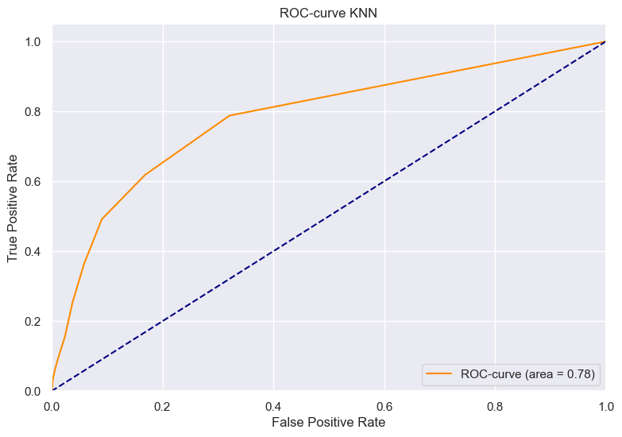

```python
plt.plot(fpr, tpr, color='darkorange',
         label='ROC-curve (area = %0.2f)' % roc_auc)
plt.plot([0, 1], [0, 1], color='navy', linestyle='--')
plt.xlim([0.0, 1.0])
plt.ylim([0.0, 1.05])
plt.xlabel('False Positive Rate')
plt.ylabel('True Positive Rate')
plt.title('ROC-curve KNN')
plt.legend(loc="lower right")
plt.show()
```

```python
predproba_grid_rfc = grid_rfc.predict_proba(X_test)
predproba_grid_rfc = predproba_grid_rfc[:,1]
grid_rfc_auc = roc_auc_score(y_test, predproba_grid_rfc)
print('KNN: ROC AUC=%.3f' % (grid_rfc_auc))
```

```
KNN: ROC AUC=0.837
```

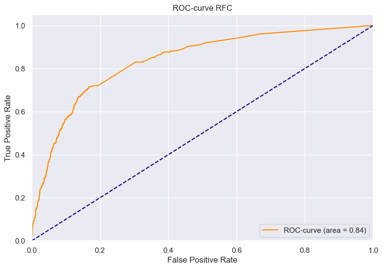

```python
fpr, tpr, treshold = roc_curve(y_test, predproba_grid_rfc)
roc_auc = auc(fpr, tpr)
plt.plot(fpr, tpr, color='darkorange',
         label='ROC-curve (area = %0.2f)' % roc_auc)
plt.plot([0, 1], [0, 1], color='navy', linestyle='--')
plt.xlim([0.0, 1.0])
plt.ylim([0.0, 1.05])
plt.xlabel('False Positive Rate')
plt.ylabel('True Positive Rate')
plt.title('ROC-curve RFC')
plt.legend(loc="lower right")
plt.show()
```

```python
xgbc = XGBClassifier(
    objective= 'binary:logistic',
    nthread=4,
    seed=42
)

parameters = {
    'max_depth': range (2, 10, 1),
    'n_estimators': range(60, 220, 40),
    'learning_rate': [0.1, 0.01, 0.05]
}
```

```python
grid_search_xgbc = GridSearchCV(
    estimator=xgbc,
    param_grid=parameters,
    scoring = 'roc_auc',
    n_jobs = 10,
    cv = 10,
    verbose=True
)
```

```python
grid_search_xgbc.fit(X_train,y_train)
```

```
Fitting 10 folds for each of 96 candidates, totalling 960 fits
```

```
GridSearchCV(cv=10,
             estimator=XGBClassifier(base_score=None, booster=None,
                                     callbacks=None, colsample_bylevel=None,
                                     colsample_bynode=None,
                                     colsample_bytree=None,
                                     early_stopping_rounds=None,
                                     enable_categorical=False, eval_metric=None,
                                     feature_types=None, gamma=None,
                                     gpu_id=None, grow_policy=None,
                                     importance_type=None,
                                     interaction_constraints=None,
                                     learning_rate=None...
                                     max_cat_to_onehot=None,
                                     max_delta_step=None, max_depth=None,
                                     max_leaves=None, min_child_weight=None,
                                     missing=nan, monotone_constraints=None,
                                     n_estimators=100, n_jobs=None, nthread=4,
                                     num_parallel_tree=None, predictor=None, ...),
             n_jobs=10,
             param_grid={'learning_rate': [0.1, 0.01, 0.05],
                         'max_depth': range(2, 10),
                         'n_estimators': range(60, 220, 40)},
             scoring='roc_auc', verbose=True)
```

```python
grid_search_xgbc.best_estimator_
```

```
XGBClassifier(base_score=None, booster=None, callbacks=None,
              colsample_bylevel=None, colsample_bynode=None,
              colsample_bytree=None, early_stopping_rounds=None,
              enable_categorical=False, eval_metric=None, feature_types=None,
              gamma=None, gpu_id=None, grow_policy=None, importance_type=None,
              interaction_constraints=None, learning_rate=0.05, max_bin=None,
              max_cat_threshold=None, max_cat_to_onehot=None,
              max_delta_step=None, max_depth=2, max_leaves=None,
              min_child_weight=None, missing=nan, monotone_constraints=None,
              n_estimators=140, n_jobs=None, nthread=4, num_parallel_tree=None,
              predictor=None, ...)
```

```python
predproba_grid_search_xgbc = grid_search_xgbc.predict_proba(X_test)
predproba_grid_search_xgbc = predproba_grid_search_xgbc[:,1]
grid_search_xgbc_auc = roc_auc_score(y_test, predproba_grid_search_xgbc)
print('grid_search_xgbc: ROC AUC=%.3f' % (grid_search_xgbc_auc))
```

```
grid_search_xgbc: ROC AUC=0.840
```

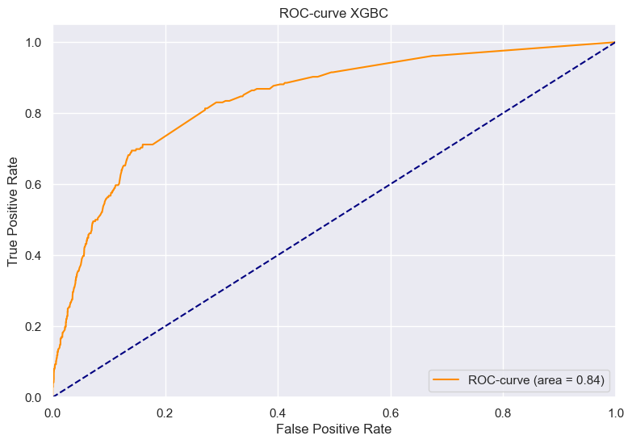

```python
fpr, tpr, treshold = roc_curve(y_test, predproba_grid_search_xgbc)
roc_auc = auc(fpr, tpr)
plt.plot(fpr, tpr, color='darkorange',
         label='ROC-curve (area = %0.2f)' % roc_auc)
plt.plot([0, 1], [0, 1], color='navy', linestyle='--')
plt.xlim([0.0, 1.0])
plt.ylim([0.0, 1.05])
plt.xlabel('False Positive Rate')
plt.ylabel('True Positive Rate')
plt.title('ROC-curve XGBC')
plt.legend(loc="lower right")
plt.show()
```

```python
grid_rfc.score(X_test,y_test)
```

```
0.9335557408951904
```

```python
xgbc_pred = grid_search_xgbc.predict(X_test)
xgbc_acc = accuracy_score(y_test, xgbc_pred)
```

```python
models = pd.DataFrame({'model': ['Random forest', 'k Nearest Neighbor', 'XGBoost'],
                       'Score': [grid_rfc.score(X_test,y_test),knn_grid.score(X_test,y_test),xgbc_acc],
                      'ROC_AUC' : [grid_rfc_auc,knn_grid_auc,grid_search_xgbc_auc]
                      })
```

Here you can see the accuracy score and ROC-AUC of 3 models. According to evaluation the most accurate model is **XGBoost model**.

```python
models
```

|  | model | Score | ROC_AUC |
| --- | --- | --- | --- |
| 0 | Random forest | 0.933556 | 0.837001 |
| 1 | k Nearest Neighbor | 0.930220 | 0.782713 |
| 2 | XGBoost | 0.935224 | 0.839993 |

### Conclusion

In this project, you can see the complete process of building a classification model, including:

- Data Obtaining
- Data Cleaning
- Data Visualizing
- Data Modeling
- Data Interpreting